# hw6_lm_FHChang

Feng-Hsun Chang

2016.Oct.17

First I read in data from my own GitHub repository

```r
library(RCurl)
library(plyr)
library(dplyr)
library(tidyr)
library(ggplot2)
library(grid)
library(gridExtra)
library(lmtest)
library(scales)
dat1_raw=read.csv(text=getURL("https://raw.githubusercontent.com/OscarFHC/EEB480_ModelInfer_assignment/master/Mod_Infer_hw6/Parus_major_Wytham_Wood.csv"), sep=",", header=T,comment.char="#")
dat2_raw=read.csv(text=getURL("https://raw.githubusercontent.com/OscarFHC/EEB480_ModelInfer_assignment/master/Mod_Infer_hw6/Thrips_imaginis_Davidson1948.csv"), sep=",", header=T,comment.char="#")
parus = dat1_raw %>%
  rename(yr=Sample.Date, pop.nat=Population)
thrip = dat2_raw %>%
  mutate(yr=Sample.Date%/%1,
         month=round(100*(Sample.Date%%1)),
         time=yr+month/12,
         pop.nat=Population,
         Population=NULL,
         Sample.Date=NULL)
```

# Exercise 1

Here I plot the time series of each data set in untransformed population size (pop.nat), squared root-transformed population size (pop.sqrt) and log-transformed population size (pop.log).

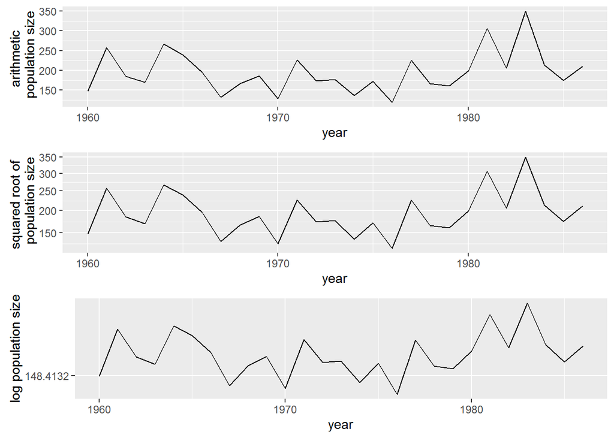

```r
parus.nat = ggplot(data=parus, aes(x=yr, y=pop.nat))+
              geom_line()+
              scale_y_continuous()+
              labs(x="year", y="arithmetic \n population size")
parus.sqrt = ggplot(data=parus, aes(x=yr, y=pop.nat))+
              geom_line()+
              scale_y_continuous(trans="sqrt")+
              labs(x="year", y="squared root of \n population size")
parus.log = ggplot(data=parus, aes(x=yr, y=pop.nat))+
              geom_line()+
              scale_y_continuous(trans="log")+
              labs(x="year", y="log population size")
grid.arrange(parus.nat, parus.sqrt, parus.log, ncol=1)
```

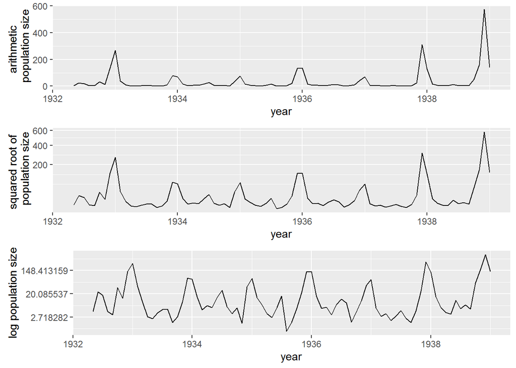

```r
thrip.nat = ggplot(data=thrip, aes(x=time, y=pop.nat))+
              geom_line()+
              scale_y_continuous()+
              labs(x="year", y="arithmetic \n population size")
thrip.sqrt = ggplot(data=thrip, aes(x=time, y=pop.nat))+
              geom_line()+
              scale_y_continuous(trans="sqrt")+
              labs(x="year", y="squared root of \n population size")
thrip.log = ggplot(data=thrip, aes(x=time, y=pop.nat))+
              geom_line()+
              scale_y_continuous(trans="log")+
              labs(x="year", y="log population size")
grid.arrange(thrip.nat, thrip.sqrt, thrip.log, ncol=1)
```

Here I found that, among the three transformations of the population size, the dynamics of parus population (the first figure) are more similar than those of thrip population. This is due to the fact the range of the data are more widely distributed in thrip population. Therefore, the effects of transformation on thrip data are more obvious. From the table below, we see that thrips data expands almost 3 orders of magnitude, while the parus data only expands less than half an order of magnitude.

```r
list(parus=parus,thrips=thrip) %>%
  ldply(.id='dataset') %>%
  ddply(~dataset,summarize,range=diff(range(log10(pop.nat))))
```

```
##   dataset     range
## 1   parus 0.4685211
## 2  thrips 2.8562756
```

# Exercise 2

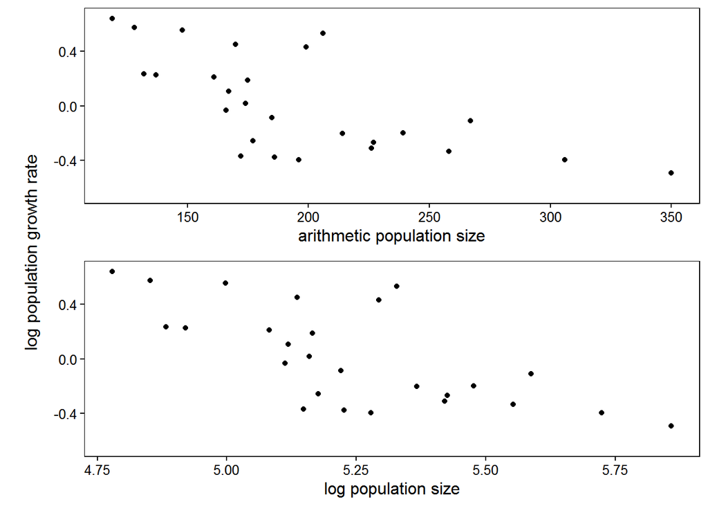

```r
parus.ex2 = parus  %>%
  mutate(pop.log=log(pop.nat)) %>%
  mutate(ratio=c(log(parus[,"pop.nat"][2:nrow(parus)]/parus[,"pop.nat"][1:(nrow(parus)-1)]), "NA")) %>%
  filter(ratio!="NA") %>%
  mutate(ratio=as.numeric(ratio))

p1= ggplot(data=parus.ex2, aes(x=pop.nat, y=ratio))+
    geom_point()+
    labs(x="arithmetic population size", y="")+
    ylim(-0.65, 0.65)+
    theme_bw()+
    theme(panel.grid.major=element_blank(),
          panel.grid.minor=element_blank(),
          strip.background = element_blank(),
          panel.border=element_rect(color="black"))
p2= ggplot(data=parus.ex2, aes(x=pop.log, y=ratio))+
    geom_point()+
    labs(x="log population size", y="")+
    ylim(-0.65, 0.65)+
    theme_bw()+
    theme(panel.grid.major=element_blank(),
          panel.grid.minor=element_blank(),
          strip.background = element_blank(),
          panel.border=element_rect(color="black"))

grid.arrange(p1, p2, ncol=1, left=textGrob("log population growth rate", rot=90, vjust=2))
```

The parus data set returns me similar patterns and both of them show a negative relationship, which possibly indicates a existence of density dependency.

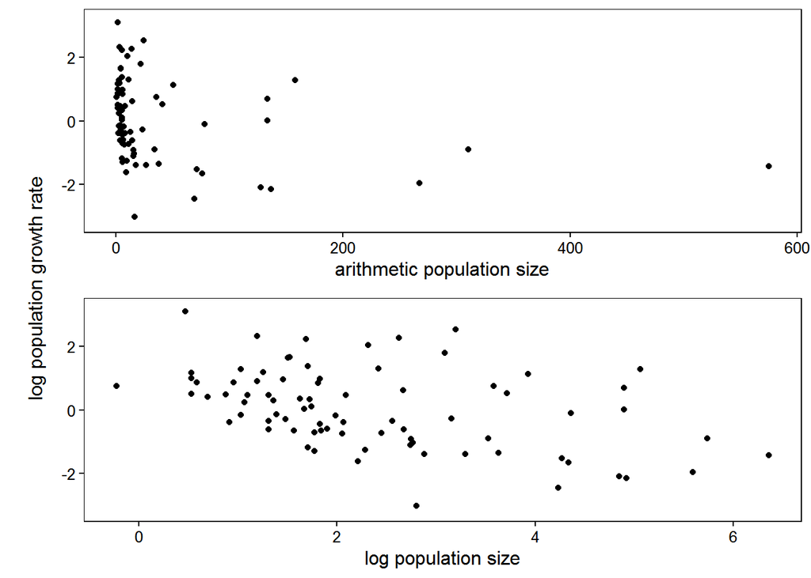

```r
thrip.ex2 = thrip  %>%
  mutate(pop.log=log(pop.nat)) %>%
  mutate(ratio=c(log(thrip[,"pop.nat"][2:nrow(thrip)]/thrip[,"pop.nat"][1:(nrow(thrip)-1)]), "NA")) %>%
  filter(ratio!="NA") %>%
  mutate(ratio=as.numeric(ratio))

p1= ggplot(data=thrip.ex2, aes(x=pop.nat, y=ratio))+
    geom_point()+
    labs(x="arithmetic population size", y="")+
    ylim(-3.2, 3.2)+
    theme_bw()+
    theme(panel.grid.major=element_blank(),
          panel.grid.minor=element_blank(),
          strip.background = element_blank(),
          panel.border=element_rect(color="black"))
p2= ggplot(data=thrip.ex2, aes(x=pop.log, y=ratio))+
    geom_point()+
    labs(x="log population size", y="")+
    ylim(-3.2, 3.2)+
    theme_bw()+
    theme(panel.grid.major=element_blank(),
          panel.grid.minor=element_blank(),
          strip.background = element_blank(),
          panel.border=element_rect(color="black"))

grid.arrange(p1, p2, ncol=1, left=textGrob("log population growth rate", rot=90, vjust=2))
```

The thrip data only shows a slightly negative trend when the population size is log-transformed. Although there is also a negative relationship between per capita growth rate versus population size, it could be dominated by those measurements of large population size. This implies it might not be proper to fit the Ricker model to the thrip data as the error of the population size of thrip is probably not normally distributed.

# Exercise 3 and 4

```r
parus.lm.ricker=lm(ratio~pop.nat, data=parus.ex2)
parus.r.ricker=parus.lm.ricker$coefficients[1]
parus.K.ricker=-(parus.lm.ricker$coefficients[1]/parus.lm.ricker$coefficients[2])

parus.lm.gomp=lm(ratio~pop.log, data=parus.ex2)
parus.r.gomp=-log(-parus.lm.gomp$coefficients[2])
parus.K.gomp=exp(parus.lm.gomp$coefficients[1]/-(parus.lm.gomp$coefficients[2]))
```

In the Parus data set, the carrying capacity of parus is estimated to be 198.7591214 in the Ricker model and 191.7407992 in the Gompertz model. The two estimates of carrying capacity are pretty similar. However, the two estimates of the intrinsic growth rate (0.8519642 in the Ricker model and 0.0661205 in the Gompertz model) in two model differ more than one order of magnitude. This is intriguing because the patters of the two relationships are so similar.

This is because the $r$ in two models are describing the population dynamics in a different ways. For example, given the same $r$ (say 0.1) and same $K$ (say 195), when $N_{t-1}$ is very small (say 0.0001), $log\frac{N_t} {N_{t-1}}$ in the Ricker model is 0.0999999 but it is 13.1050679 in the Gompertz model. However, there should only be one value of $log\frac{N_t} {N_{t-1}}$, since it is the same population under the same condition. The meaning of at least $r$ in the two models are different.

```r
thrip.lm.ricker=lm(ratio~pop.nat, data=thrip.ex2)
thrip.r.ricker=thrip.lm.ricker$coefficients[1]
thrip.K.ricker=-(thrip.lm.ricker$coefficients[1]/thrip.lm.ricker$coefficients[2])

thrip.lm.gomp=lm(ratio~pop.log, data=thrip.ex2)
thrip.r.gomp=-log(-thrip.lm.gomp$coefficients[2])
thrip.K.gomp=exp(thrip.lm.gomp$coefficients[1]/-(thrip.lm.gomp$coefficients[2]))
```

In the Thrips data set, both the intrinsic growth rate (0.2007565 in the Ricker model vs 0.9801472 in the Gompertz model) and carrying capacity (44.719862 in the Ricker model vs 11.6748516 in the Gompertz model) estimated by both model are so different from each other. Although the Gompertz model performs slightly better than the Ricker model and returns a statistically significant slope, both model have poor explanation to the variation of per capita growth rate. Judging from only this analysis, one could conclude that the density dependency does not exist or at least not strong enough to be detected. However, other factors could be influencing the density dependency, like seasonality, which I would be able to see it in the following exercises.

# Exercise 5

Here I first use dots to indicate the observed growth rate and blue line to indicate the fitted growth rate versus population size in arithmetic scale (upper panel; Ricker model) and in log scale (lower panel; Gompertz model) for Parus data set. This is basically plot the fitted line onto the plot in exercise 2.

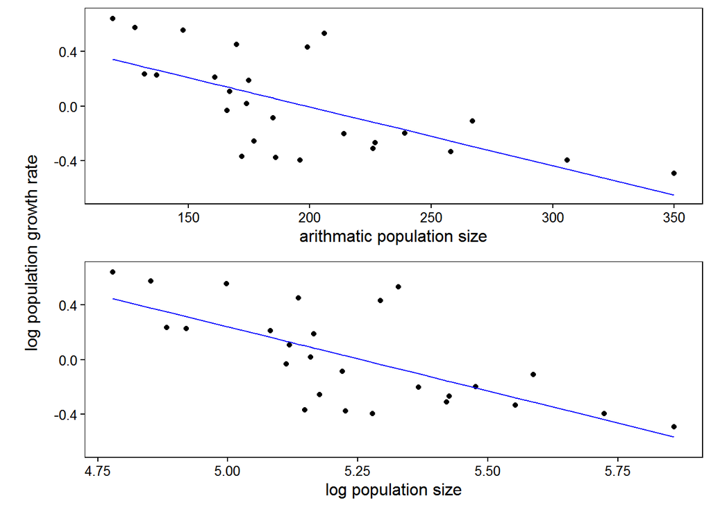

```r
parus.ex2 = parus.ex2  %>%
  mutate(rick.fit=predict(parus.lm.ricker), gomp.fit=predict(parus.lm.gomp))

p1= ggplot(data=parus.ex2)+
    geom_point(aes(x=pop.nat, y=ratio), col="black")+
    geom_line(aes(x=pop.nat, y=rick.fit), col="blue")+
    labs(x="arithmatic population size", y="")+
    ylim(-0.65, 0.65)+
    theme_bw()+
    theme(panel.grid.major=element_blank(),
          panel.grid.minor=element_blank(),
          strip.background = element_blank(),
          panel.border=element_rect(color="black"))
p2= ggplot(data=parus.ex2, aes(x=pop.nat, y=ratio))+
    geom_point(aes(x=pop.log, y=ratio), col="black")+
    geom_line(aes(x=pop.log, y=gomp.fit), col="blue")+
    labs(x="log population size", y="")+
    ylim(-0.65, 0.65)+
    theme_bw()+
    theme(panel.grid.major=element_blank(),
          panel.grid.minor=element_blank(),
          strip.background = element_blank(),
          panel.border=element_rect(color="black"))

grid.arrange(p1, p2, ncol=1, left=textGrob("log population growth rate", rot=90, vjust=2))
```

In the Parus data set, the two density dependency models fit fairly well. More than 40% of the variance of $log\frac{N_t} {N_{t-1}}$ is explained by the model (0.41 in the Ricker model and 0.45 in the Gomprtz model.).  
Next, I do the same thing with the thrip data set.

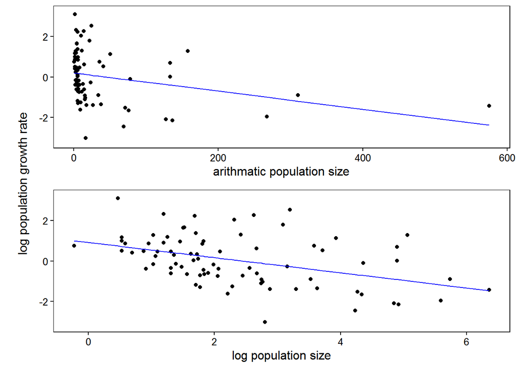

```r
thrip.ex2 = thrip.ex2  %>%
  mutate(rick.fit=predict(thrip.lm.ricker), gomp.fit=predict(thrip.lm.gomp))

p1= ggplot(data=thrip.ex2)+
    geom_point(aes(x=pop.nat, y=ratio), col="black")+
    geom_line(aes(x=pop.nat, y=rick.fit), col="blue")+
    labs(x="arithmatic population size", y="")+
    ylim(-3.2, 3.2)+
    theme_bw()+
    theme(panel.grid.major=element_blank(),
          panel.grid.minor=element_blank(),
          strip.background = element_blank(),
          panel.border=element_rect(color="black"))
p2= ggplot(data=thrip.ex2, aes(x=pop.nat, y=ratio))+
    geom_point(aes(x=pop.log, y=ratio), col="black")+
    geom_line(aes(x=pop.log, y=gomp.fit), col="blue")+
    labs(x="log population size", y="")+
    ylim(-3.2, 3.2)+
    theme_bw()+
    theme(panel.grid.major=element_blank(),
          panel.grid.minor=element_blank(),
          strip.background = element_blank(),
          panel.border=element_rect(color="black"))

grid.arrange(p1, p2, ncol=1, left=textGrob("log population growth rate", rot=90, vjust=2))
```

In the Thrips data set, the two density dependency models do not fit well. Less than 20% of the variance of $log\frac{N_t} {N_{t-1}}$ is explained by the model (0.08 in the Ricker model and 0.17 in the Gompertz model.)

> But does one appear to fit better, according to the plots? Can you plot both models with the data on a single pair of axes?

> OSCAR: how do you tell which one fit better if not looking at the R2?

# Exercise 6

Here I use `t-test` to test whether the slope estimation is significantly different from 0 and use `F-test` to test whether the model with explanatory variable (i.e. with intercept and slope in this case) can explain significantly more variance than the one without explanatory variable (i.e. with only intercept in this case).

```r
summary(parus.lm.ricker)
```

```
##
## Call:
## lm(formula = ratio ~ pop.nat, data = parus.ex2)
##
## Residuals:
##     Min      1Q  Median      3Q     Max
## -0.4831 -0.1445 -0.0328  0.1754  0.5611
##
## Coefficients:
##              Estimate Std. Error t value Pr(>|t|)
## (Intercept)  0.851964   0.203216   4.192 0.000324 ***
## pop.nat     -0.004286   0.001002  -4.278 0.000260 ***
## ---
## Signif. codes:  0 '***' 0.001 '**' 0.01 '*' 0.05 '.' 0.1 ' ' 1
##
## Residual standard error: 0.2744 on 24 degrees of freedom
## Multiple R-squared:  0.4326, Adjusted R-squared:  0.409
## F-statistic:  18.3 on 1 and 24 DF,  p-value: 0.0002605
```

```r
anova(parus.lm.ricker)
```

```
## Analysis of Variance Table
##
## Response: ratio
##           Df Sum Sq Mean Sq F value    Pr(>F)
## pop.nat    1 1.3780 1.37797  18.301 0.0002605 ***
## Residuals 24 1.8071 0.07529
## ---
## Signif. codes:  0 '***' 0.001 '**' 0.01 '*' 0.05 '.' 0.1 ' ' 1
```

The significance of the population size in the `t-test` indicates the influences of population size on $log\frac{N_t} {N_{t-1}}$ is significantly different from 0 (the purpose of `t-test`). The significance in the `F-test` indicates the model with population size as explanatory variable explains greater amount of variance of $log\frac{N_t} {N_{t-1}}$ than the model without population size as explanatory variable.

In terms of the amount of variance being explained, we can see that the `t-test` performed on the slope estimation is identical to the `F-test` performed on the model. This is because the influences of a explanatory variable in a model is the amount of variance explained by this explanatory variable. In this case, after include population size as explanatory variable, sum of squared error is being reduced from 3.185 (this is the total sum of square) to 1.807. The amount of this reduction is the $R^2$ estimated in the linear model (0.433).

In terms of the significance of the influence of population size, p value from the `t-test` performed on the slope estimation is identical to the `F-test` performed on the model. The probability for the model without population size as explanatory variable to reduce the same amount of sum of square error is $2.6045796\times 10^{-4}$ (i.e. the results from `t-test`). This probability is identical to the p value in the `F-test` ($2.6\times 10^{-4}$).

# Exercise 7

Here I first calculate the 95%, 90%, 80%, 60% confidence intervals of the two parameters in the Ricker model and overlay these confidence intervals onto the fitted linear model (blue line). The black dots represent the original data points.

```r
confint(parus.lm.ricker, level=0.95)
```

```
##                    2.5 %       97.5 %
## (Intercept)  0.432546551  1.271381946
## pop.nat     -0.006354373 -0.002218458
```

```r
confint(parus.lm.ricker, level=0.90)
```

```
##                      5 %         95 %
## (Intercept)  0.504285231  1.199643265
## pop.nat     -0.006000663 -0.002572169
```

```r
confint(parus.lm.ricker, level=0.80)
```

```
##                     10 %         90 %
## (Intercept)  0.584158590  1.119769907
## pop.nat     -0.005606843 -0.002965988
```

```r
confint(parus.lm.ricker, level=0.60)
```

```
##                     20 %         80 %
## (Intercept)  0.677837307  1.026091190
## pop.nat     -0.005144956 -0.003427875
```

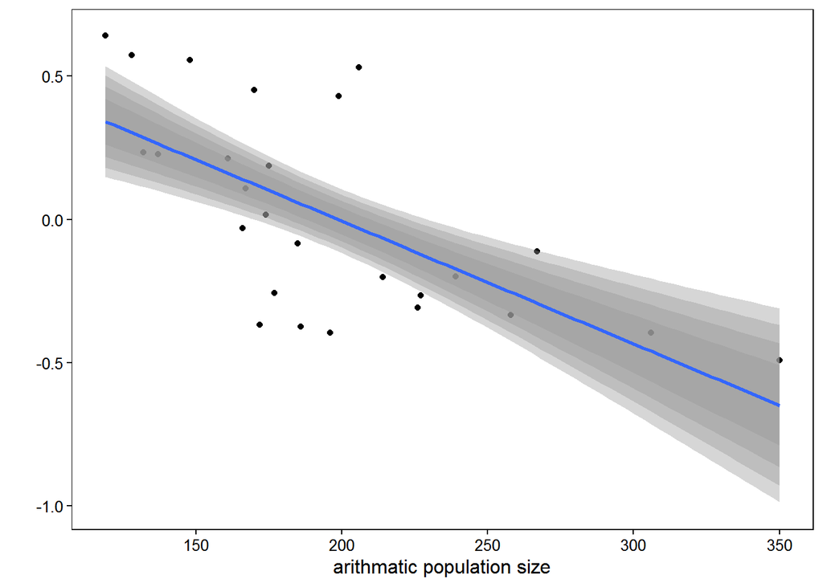

```r
ggplot(data=parus.ex2,aes(x=pop.nat, y=ratio))+
    geom_point(col="black")+
    geom_line(aes(x=pop.nat, y=rick.fit), col="blue")+
    stat_smooth(method="lm", level=0.95)+
    stat_smooth(method="lm", level=0.90)+
    stat_smooth(method="lm", level=0.80)+
    stat_smooth(method="lm", level=0.60)+
    labs(x="arithmatic population size", y="")+
    ylim(-1, 0.65)+
    theme_bw()+
    theme(panel.grid.major=element_blank(),
          panel.grid.minor=element_blank(),
          strip.background = element_blank(),
          panel.border=element_rect(color="black"))
```

# Exercise 8

To calculate the standard error of carrying capacity by the delta method, I first use `lm()` function to estimate the $\hat{\beta}$ matrix, which I name it “B”. Then I calculate the variance-covariance matrix of this $\hat{\beta}$ matrix. I also write a transformation function that transforms the $\hat{\beta_i}$ I derive from the linear model to the r and K in the Ricker model. Finally, according to the “delta method”, the variance (or standard error) of the transformed parameters could be approximated by
$$JVar[\hat{\beta}]J^T$$
, where $J$ is the Jacobian matrix of the $\hat{\beta}$ matrix and $Var[\beta]$ is the variance-covariance of the $hat{\beta}$ matrix.

I found three methods to calculate the standard error of r and K.  
1. Derive and code the transformation matrix ($\theta$) that transform $\hat{\beta}$ matrix to r and K in the Ricker model. Then use the numerical solver in R calculate the Jacobian matrix evaluated at $\hat{\beta}$.  
2. Derive and code the Jacobian matrix ($J$) manually and evaluate it at the $\hat{\beta}$ matrix.  
3. Use a package (`msm`) that calculate it.

Here I show the first and third method to calculat the standard error for r and K parameter in the Ricker model.

```r
B.rick = summary(parus.lm.ricker)$coefficients[,1]
vcovB.rick = vcov(parus.lm.ricker) # variance-covariance matrix of the linear model (Ricker model)

theta.rick = function(M){ # transformation function from coefficients to theta (carrying capacity in this case)
  theta1 = M[1]
  theta2 = -(M[1]/M[2])
  c(theta1, theta2)
}

#install.packages("numDeriv")
# Here I installed a package to calculate the Jacobian matrix evaluated at the beta = beta hat
library(numDeriv)

se.rick = sqrt(diag( jacobian(theta.rick, B.rick) %*% vcovB.rick %*% t(jacobian(theta.rick, B.rick)) ))
se.rick
```

```
## [1]  0.2032162 12.5764799
```

> Come on, Oscar, a little calculus won’t kill you! OSCAR: I’m dead…

The standard error of the r and K parameter in the Ricker model are 0.2032162 and 12.5764799 respectively.  
Here is the third method that allows me to calculate the standard error of a parameter that is being transformed from the coefficients estimated in a model.

```r
library(msm)
deltamethod(~ x1, coef(parus.lm.ricker), vcov(parus.lm.ricker))
```

```
## [1] 0.2032162
```

```r
deltamethod(~ -(x1/x2), coef(parus.lm.ricker), vcov(parus.lm.ricker))
```

```
## [1] 12.57648
```

The standard error estimated by the two methods are the same, so this calculation should be correct.

Here I go on to calculate the standard error of the carrying capacity in the Gompertz model with the second method.

```r
B.gomp = summary(parus.lm.gomp)$coefficients[,1]
vcovB.gomp = vcov(parus.lm.gomp) # variance-covariance matrix of the linear model (Ricker model)

Jacb.gomp = function(Beta){
  f1 = c(0, -1/Beta[2])
  f2 = c(exp(-Beta[1]/Beta[2])*(-1/Beta[2]), exp(-Beta[1]/Beta[2])*(Beta[1]/(Beta[2]^2)))
  as.matrix(rbind(f1, f2))
}

se.gomp = sqrt(diag( Jacb.gomp(B.gomp) %*% vcovB.gomp %*% t(Jacb.gomp(B.gomp)) ))
```

The standard error of the r and K parameter in the Gompertz model are 0.214295 and 10.6138606 respectively.

# Exercise 9

Here, I compare the $R^2$ and adjusted $R^2$ in both the Ricker and Gompertz models to judge which one explain the model better. Specifically, I first calculate the total sum of square (SST) and residual sum of square (SSR) for both models. $1-SSR/SST$ is the $R^2$, which is also the amount of variance being explained by the explanatory variable. After corrected SST and SSR with their corresponding degree of freedom, the adjusted $R^2$ can be calculated. Therefore adjusted $R^2$ takes number of explanatory variable into account as increasing number of explanatory variable will decrease the degree of freedom of SSR, so decrease the adjusted $R^2$.

```r
parus.lm.ricker=lm(ratio~pop.nat, data=parus.ex2)
#summary(parus.lm.ricker)
SST.r = var(parus.ex2[,"ratio"])*(nrow(parus.ex2)-1)
SSR.r = sum(residuals(parus.lm.ricker)^2)
R2.r = 1-(SSR.r/SST.r)
R2.r.adj = 1-(SSR.r/(nrow(parus.ex2)-2))/(SST.r/(nrow(parus.ex2)-1))
```

The $R^2$ of the Ricker model is 0.4326416 and the adjusted $R^2$ is 0.4090017.  
Following the same fashion, I calculated the $R^2$ and adjusted $R^2$ for the Gompertz model.

```r
parus.lm.gomp=lm(ratio~pop.log, data=parus.ex2)
#summary(parus.lm.gomp)
SST.g = var(parus.ex2[,"ratio"])*(nrow(parus.ex2)-1)
SSR.g = sum(residuals(parus.lm.gomp)^2)
R2.g = 1-(SSR.g/SST.g)
R2.g.adj = 1-(SSR.g/(nrow(parus.ex2)-2))/(SST.g/(nrow(parus.ex2)-1))
```

The $R^2$ of the Gompertz model is 0.4757067 and the adjusted $R^2$ is 0.4538611.

Since the two models are using the same data and have same number of explanatory variables. The difference between $R^2$ and adjusted $R^2$ should mean the same thing. However, since the adjusted $R^2$ is the unbiased estimate, I think we should use adjust $R^2$ to judge which model fit the data better. From the difference between adjusted $R^2$, we can see that the Gompertz model explain about 4.49 % more variance than the Ricker model.

# Exercise 10

## Ex 10.1 Gompertz model and the Ricker model for Thrips data set.

Here, I use the Thrips data set to do the same analysis as those have been done in exercise 9.

```r
thrip.lm.ricker=lm(ratio~pop.nat, data=thrip.ex2)
SST.r = var(thrip.ex2[,"ratio"])*(nrow(thrip.ex2)-1)
SSR.r = sum(residuals(thrip.lm.ricker)^2)
R2.r = 1-(SSR.r/SST.r)
R2.r.adj = 1-(SSR.r/(nrow(thrip.ex2)-2))/(SST.r/(nrow(thrip.ex2)-1))
```

The $R^2$ of the Ricker model is 0.0869086 and the adjusted $R^2$ is 0.0752023.

```r
thrip.lm.gomp=lm(ratio~pop.log, data=thrip.ex2)
SST.g = var(thrip.ex2[,"ratio"])*(nrow(thrip.ex2)-1)
SSR.g = sum(residuals(thrip.lm.gomp)^2)
R2.g = 1-(SSR.g/SST.g)
R2.g.adj = 1-(SSR.g/(nrow(thrip.ex2)-2))/(SST.g/(nrow(thrip.ex2)-1))
```

The $R^2$ of the Gompertz model is 0.1787636 and the adjusted $R^2$ is 0.1682349.

Similarly, from the difference between adjusted $R^2$, we can see that the Gompertz model explain about 9.3 % more variance than the Ricker model.

## Ex 10.2 Adjust $R^2$

Exploring the adjust $R^2$ value with different combination of independent variables in the Gompertz model.

To do so, I first inspect if there is any temporal structure in the Thrips data set. I use `acf()` function to inspect the temporal auto correlation.

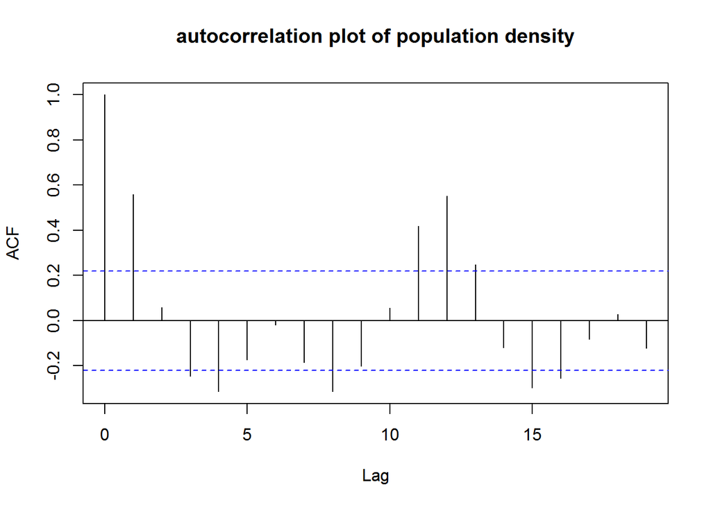

```r
acf(thrip.ex2$pop.log, main="autocorrelation plot of population density")
```

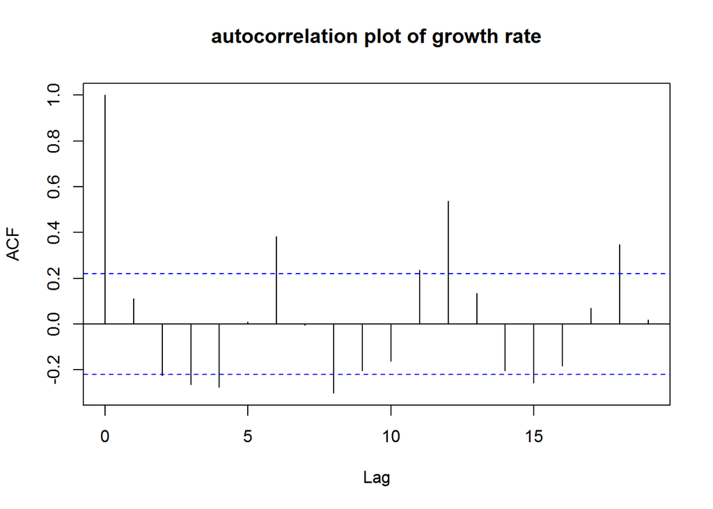

```r
acf(thrip.ex2$ratio, main="autocorrelation plot of growth rate")
```

I therefore fit the linear model with interaction terms of population size and each month. By doing so, I can inspect whether the influences of population size on $log\frac{N_t} {N_{t-1}}$ are different in different month.

```r
thrip.ex2[,"month"]=as.factor(thrip.ex2[,"month"])
thrip.lm.gomp=lm(ratio~pop.log, data=thrip.ex2)
summary(thrip.lm.gomp)
```

```
##
## Call:
## lm(formula = ratio ~ pop.log, data = thrip.ex2)
##
## Residuals:
##     Min      1Q  Median      3Q     Max
## -2.8967 -0.8548 -0.1965  0.7130  2.8199
##
## Coefficients:
##             Estimate Std. Error t value Pr(>|t|)
## (Intercept)  0.92217    0.24846   3.711 0.000385 ***
## pop.log     -0.37526    0.09107  -4.121 9.34e-05 ***
## ---
## Signif. codes:  0 '***' 0.001 '**' 0.01 '*' 0.05 '.' 0.1 ' ' 1
##
## Residual standard error: 1.138 on 78 degrees of freedom
## Multiple R-squared:  0.1788, Adjusted R-squared:  0.1682
## F-statistic: 16.98 on 1 and 78 DF,  p-value: 9.343e-05
```

```r
thrip.season.gomp = lm(ratio~pop.log + pop.log:month, data=thrip.ex2)
summary(thrip.season.gomp)
```

```
##
## Call:
## lm(formula = ratio ~ pop.log + pop.log:month, data = thrip.ex2)
##
## Residuals:
##      Min       1Q   Median       3Q      Max
## -1.97497 -0.40201 -0.01209  0.41071  1.87000
##
## Coefficients:
##                 Estimate Std. Error t value Pr(>|t|)
## (Intercept)      1.14276    0.23411   4.881 6.84e-06 ***
## pop.log         -0.75549    0.12937  -5.840 1.68e-07 ***
## pop.log:month2  -0.07623    0.18749  -0.407 0.685596
## pop.log:month3  -0.21095    0.21855  -0.965 0.337912
## pop.log:month4   0.63169    0.24973   2.529 0.013783 *
## pop.log:month5   0.34086    0.15406   2.212 0.030349 *
## pop.log:month6  -0.13560    0.14465  -0.937 0.351905
## pop.log:month7  -0.30736    0.18991  -1.618 0.110263
## pop.log:month8   1.00962    0.29873   3.380 0.001214 **
## pop.log:month9   0.48916    0.14666   3.335 0.001392 **
## pop.log:month10  0.96988    0.13120   7.392 2.99e-10 ***
## pop.log:month11  0.48699    0.11789   4.131 0.000102 ***
## pop.log:month12  0.09777    0.12007   0.814 0.418364
## ---
## Signif. codes:  0 '***' 0.001 '**' 0.01 '*' 0.05 '.' 0.1 ' ' 1
##
## Residual standard error: 0.6759 on 67 degrees of freedom
## Multiple R-squared:  0.7511, Adjusted R-squared:  0.7066
## F-statistic: 16.85 on 12 and 67 DF,  p-value: 7.854e-16
```

In this improved model, I found that the interaction term of month 4, 5, 8, 9, 10, 11 are significantly different from the January term. This indicates that the influences of population size on $log\frac{N_t} {N_{t-1}}$ in these months are different from the one in month 1.

Now I compare the model considering seasonality with the one with no seasonality.

```r
anova(thrip.lm.gomp, thrip.season.gomp)
```

```
## Analysis of Variance Table
##
## Model 1: ratio ~ pop.log
## Model 2: ratio ~ pop.log + pop.log:month
##   Res.Df     RSS Df Sum of Sq      F    Pr(>F)
## 1     78 100.992
## 2     67  30.604 11    70.388 14.009 1.763e-13 ***
## ---
## Signif. codes:  0 '***' 0.001 '**' 0.01 '*' 0.05 '.' 0.1 ' ' 1
```

The one with seasonality largely improves the explanation power as it decrease the residual sum of square from 100.9917892 to 30.6040659 (total sum of square is 122.9752899). However, it still does not beat your 0.74 in adjust $R^2$

In the following I try to fit a linear mix effects model to the data to see if there is any further improvement. However, because the mixed effects model does not use ordinary least square method, so I can not extract the $R^2$ from the mixed effect model. In stead, I calculate the residual sum of square and the AIC of the two models for comparison.

```r
library(nlme)
mod.lme = lme(ratio~pop.log,data=thrip.ex2,random=~1|month)
#summary(mod_lme)
sum((thrip.ex2[,"ratio"] - predict(mod.lme))^2)
```

```
## [1] 28.71466
```

```r
sum((thrip.ex2[,"ratio"] - predict(thrip.season.gomp))^2)
```

```
## [1] 30.60407
```

```r
AIC(mod.lme)
```

```
## [1] 200.8174
```

```r
AIC(thrip.season.gomp)
```

```
## [1] 178.1587
```

The mixed effects model further reduce the residual sum of square by 2 unit. However, from the AIC value, the mixed effects model does not perform better than the simple linear model with interaction terms (AIC of the mixed effects model is 200.8174101 and AIC of the simple linear model is 178.1586644).

?? What is the model that produce your 0.74 adjust $R^2$?

> Try including seasonality in the intercept as well as the slope of the Gompertz.

```r
thrip.season.gomp1 = lm(ratio~1:month + pop.log + pop.log:month, data=thrip.ex2)
summary(thrip.season.gomp1)
```

```
##
## Call:
## lm(formula = ratio ~ 1:month + pop.log + pop.log:month, data = thrip.ex2)
##
## Residuals:
##      Min       1Q   Median       3Q      Max
## -1.97497 -0.40201 -0.01209  0.41071  1.87000
##
## Coefficients:
##                 Estimate Std. Error t value Pr(>|t|)
## (Intercept)      1.14276    0.23411   4.881 6.84e-06 ***
## pop.log         -0.75549    0.12937  -5.840 1.68e-07 ***
## month2:pop.log  -0.07623    0.18749  -0.407 0.685596
## month3:pop.log  -0.21095    0.21855  -0.965 0.337912
## month4:pop.log   0.63169    0.24973   2.529 0.013783 *
## month5:pop.log   0.34086    0.15406   2.212 0.030349 *
## month6:pop.log  -0.13560    0.14465  -0.937 0.351905
## month7:pop.log  -0.30736    0.18991  -1.618 0.110263
## month8:pop.log   1.00962    0.29873   3.380 0.001214 **
## month9:pop.log   0.48916    0.14666   3.335 0.001392 **
## month10:pop.log  0.96988    0.13120   7.392 2.99e-10 ***
## month11:pop.log  0.48699    0.11789   4.131 0.000102 ***
## month12:pop.log  0.09777    0.12007   0.814 0.418364
## ---
## Signif. codes:  0 '***' 0.001 '**' 0.01 '*' 0.05 '.' 0.1 ' ' 1
##
## Residual standard error: 0.6759 on 67 degrees of freedom
## Multiple R-squared:  0.7511, Adjusted R-squared:  0.7066
## F-statistic: 16.85 on 12 and 67 DF,  p-value: 7.854e-16
```

# Exercise 11

## 11.a

I first use the default plot function in R to inspect the goodness-of-fit of the Gompertz model and perform the Breusch-Pagan test to inspect the structure of residuals (homoscedasticity).

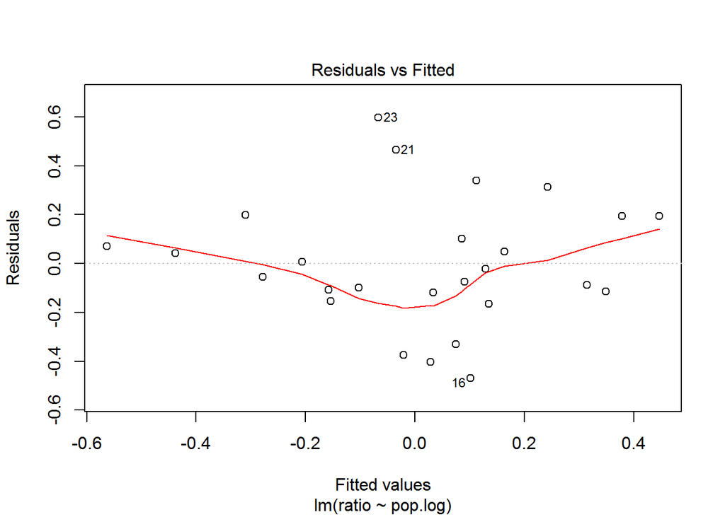

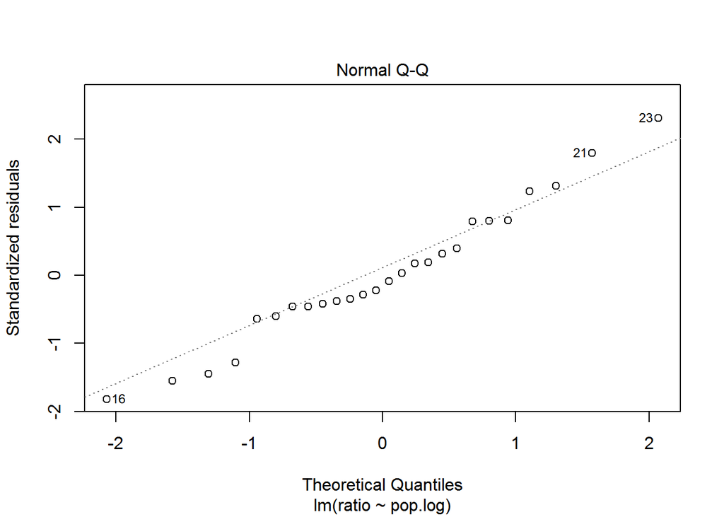

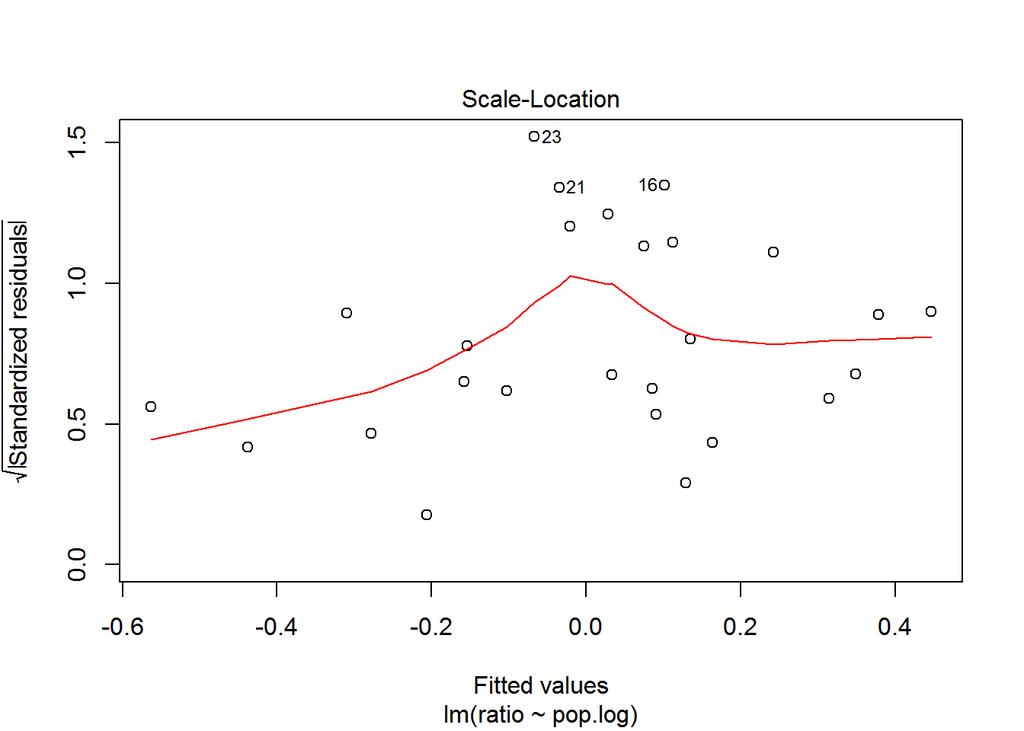

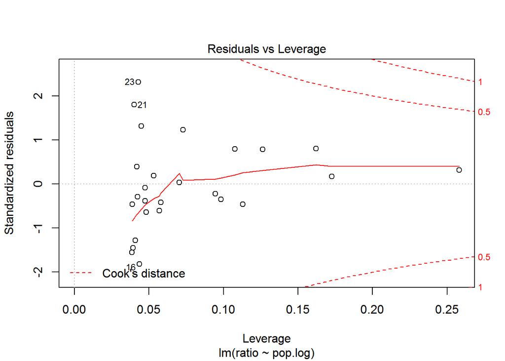

```r
plot(parus.lm.gomp)
```

```r
bptest(parus.lm.gomp)
```

```
##
##  studentized Breusch-Pagan test
##
## data:  parus.lm.gomp
## BP = 0.10856, df = 1, p-value = 0.7418
```

From the first (residuals on the y axis against fitted values on the x) and the second (normal qqnorm plot) diagnostic plots, we see not clear structure of the residuals except couple points (23, 21, 16). The Breusch-Pagan test also show nonsignificant results, which indicates that there is no statistically significant structure in the residuals. However, the scale-location plot might suggest that point 23, 21, and 16 would have slightly higher residuals.

## 11.b

Here I use Shapiro-Wilk test and QQ plot to inspect the normality of residuals.

```r
shapiro.test(residuals(parus.lm.gomp))
```

```
##
##  Shapiro-Wilk normality test
##
## data:  residuals(parus.lm.gomp)
## W = 0.97325, p-value = 0.7085
```

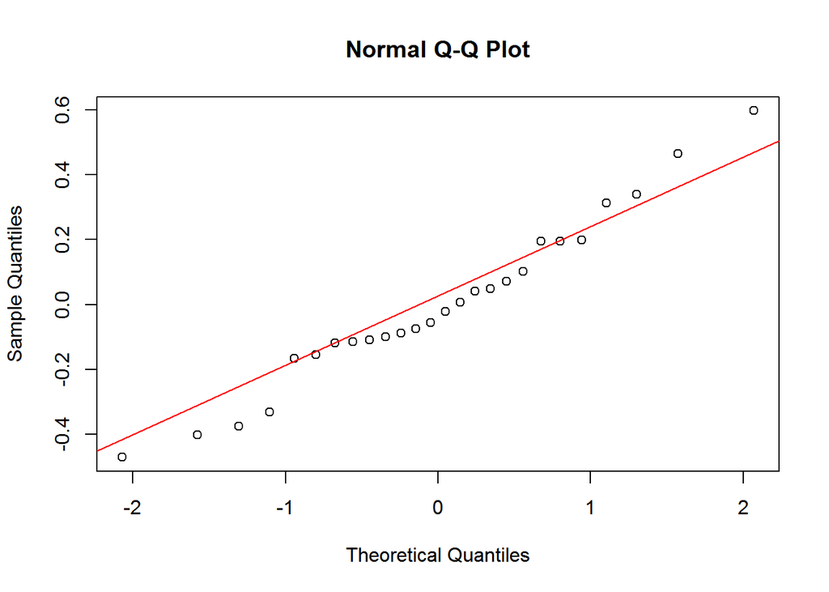

```r
qqnorm(residuals(parus.lm.gomp))
qqline(residuals(parus.lm.gomp), col="red")
```

## 11.c

From the fourth diagnostic plot (Residuals vs Leverage plot), point 23, 21 and 16 are the ones that have larger influences, but the leverage of the three are rather small. The influences of the three could be fairly small.

> How would you check?

## 11.d

Here, I use Durbin-Watson to test if there is correlation between residuals.

```r
dwtest(parus.lm.gomp)
```

```
##
##  Durbin-Watson test
##
## data:  parus.lm.gomp
## DW = 1.8625, p-value = 0.3528
## alternative hypothesis: true autocorrelation is greater than 0
```

The residuals of the Gompertz model does not show temporal auto correlation.

## 11.e

Here I calculate the standard error of the r and K parameter in the Gompertz model.

```r
summary(parus.lm.gomp)
```

```
##
## Call:
## lm(formula = ratio ~ pop.log, data = parus.ex2)
##
## Residuals:
##      Min       1Q   Median       3Q      Max
## -0.47007 -0.11711 -0.03817  0.17139  0.59720
##
## Coefficients:
##             Estimate Std. Error t value Pr(>|t|)
## (Intercept)   4.9198     1.0526   4.674 9.52e-05 ***
## pop.log      -0.9360     0.2006  -4.666 9.70e-05 ***
## ---
## Signif. codes:  0 '***' 0.001 '**' 0.01 '*' 0.05 '.' 0.1 ' ' 1
##
## Residual standard error: 0.2638 on 24 degrees of freedom
## Multiple R-squared:  0.4757, Adjusted R-squared:  0.4539
## F-statistic: 21.78 on 1 and 24 DF,  p-value: 9.697e-05
```

```r
library(msm)
parus.r.se = deltamethod(~ -log(-x2), coef(parus.lm.gomp), vcov(parus.lm.gomp))
parus.K.se = deltamethod(~ exp(x1/-(x2)), coef(parus.lm.gomp), vcov(parus.lm.gomp))
```

In the Gompertz model, the carrying capacity is estimated to be 191.741 with standard error about 10.614. This number is biologically reasonable. However, the intrinsic growth rate is the Gompertz model is estimated to be 0.066 with standard error about 0.214. The standard error of intrinsic growth rate is large so that the confidence interval of intrinsic growth rate overlaps 0. This suggests that the intrinsic growth rate estimated in the Gompertz model is not significantly different from 0, which is biologically not feasible.  
However, the standard error estimated by the delta method would no longer be valid when deviate too much from the estimated point. A profile likelihood profile of this parameter is probably required to judge the confidence interval of these parameter.  
??Question: You mentioned in your comment that this shows a skewed distribution of $r$. How do you tell thin?

# Exercise 12

Here I use the best model that includes seasonality to do the same analyses as those in exercise 11 with Thrips data set.

## 12.a

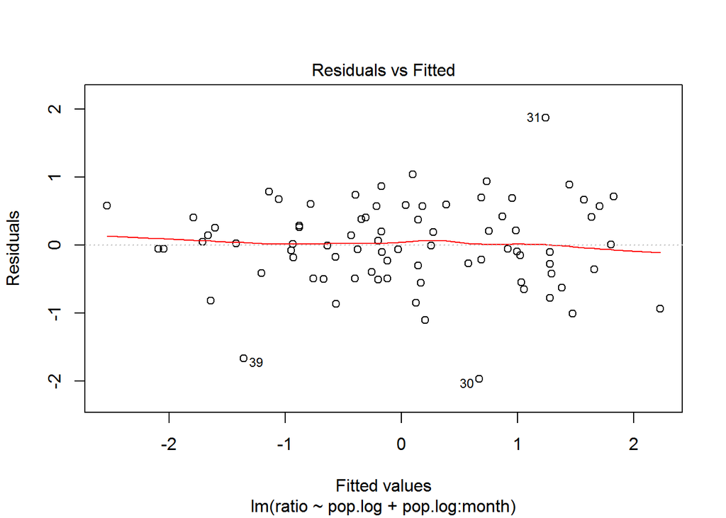

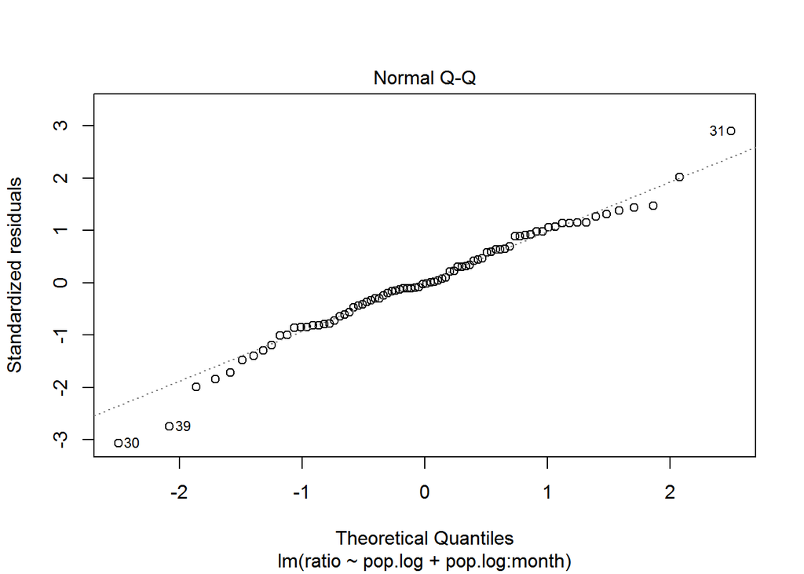

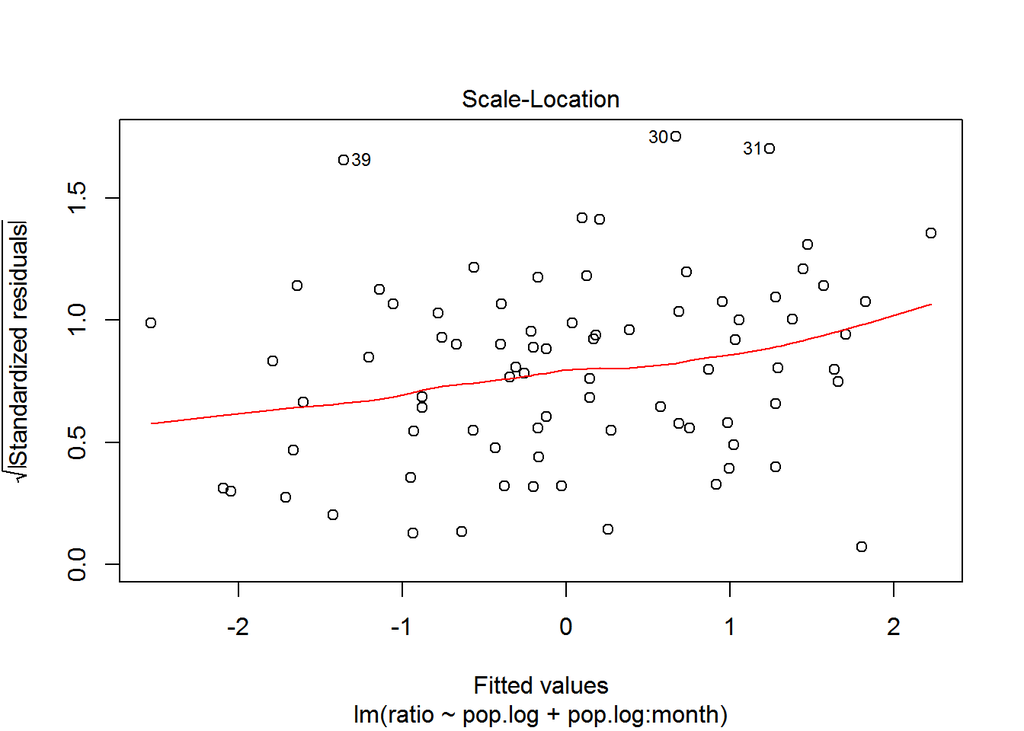

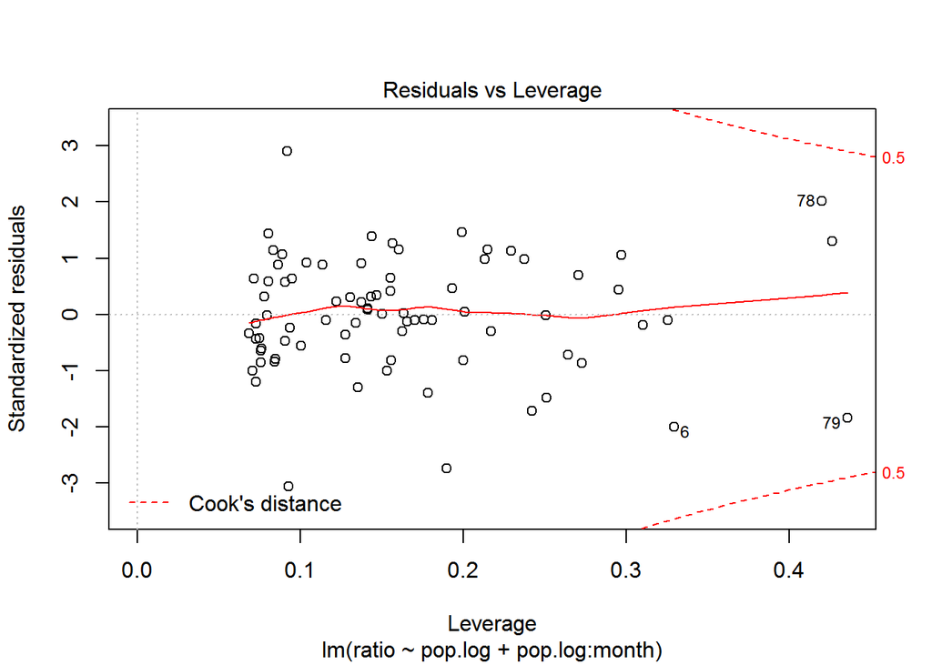

```r
plot(thrip.season.gomp)
```

```r
bptest(thrip.season.gomp)
```

```
##
##  studentized Breusch-Pagan test
##
## data:  thrip.season.gomp
## BP = 15.469, df = 12, p-value = 0.2168
```

From the 4 diagnostic plots, I see no clear structure of the residuals. The Breusch-Pagan test also suggests that the residual are homoscedasticity.

## 12.b

```r
shapiro.test(residuals(thrip.season.gomp))
```

```
##
##  Shapiro-Wilk normality test
##
## data:  residuals(thrip.season.gomp)
## W = 0.97911, p-value = 0.2149
```

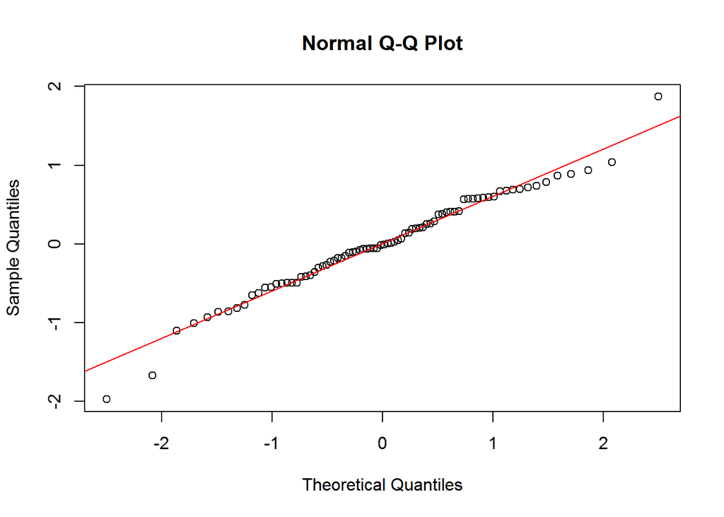

```r
qqnorm(residuals(thrip.season.gomp))
qqline(residuals(thrip.season.gomp), col="red")
```

The Shapiro-Wilk test also shows nonsignificant result. This means the residuals are normally distributed. However, from the QQ plot, only point 30, 31, and 39 might be slightly deviated from the theoretical line.

## 12.c

From the fourth diagnostic plot (Residuals vs Leverage plot), point 78 and 79 are the ones that have large leverage.

## 12.d

```r
dwtest(thrip.season.gomp)
```

```
##
##  Durbin-Watson test
##
## data:  thrip.season.gomp
## DW = 1.9022, p-value = 0.3491
## alternative hypothesis: true autocorrelation is greater than 0
```

The residuals of the Gompertz model shows no temporal autocorrelation structure in residuals.

## 12.e

```r
summary(thrip.season.gomp)
```

```
##
## Call:
## lm(formula = ratio ~ pop.log + pop.log:month, data = thrip.ex2)
##
## Residuals:
##      Min       1Q   Median       3Q      Max
## -1.97497 -0.40201 -0.01209  0.41071  1.87000
##
## Coefficients:
##                 Estimate Std. Error t value Pr(>|t|)
## (Intercept)      1.14276    0.23411   4.881 6.84e-06 ***
## pop.log         -0.75549    0.12937  -5.840 1.68e-07 ***
## pop.log:month2  -0.07623    0.18749  -0.407 0.685596
## pop.log:month3  -0.21095    0.21855  -0.965 0.337912
## pop.log:month4   0.63169    0.24973   2.529 0.013783 *
## pop.log:month5   0.34086    0.15406   2.212 0.030349 *
## pop.log:month6  -0.13560    0.14465  -0.937 0.351905
## pop.log:month7  -0.30736    0.18991  -1.618 0.110263
## pop.log:month8   1.00962    0.29873   3.380 0.001214 **
## pop.log:month9   0.48916    0.14666   3.335 0.001392 **
## pop.log:month10  0.96988    0.13120   7.392 2.99e-10 ***
## pop.log:month11  0.48699    0.11789   4.131 0.000102 ***
## pop.log:month12  0.09777    0.12007   0.814 0.418364
## ---
## Signif. codes:  0 '***' 0.001 '**' 0.01 '*' 0.05 '.' 0.1 ' ' 1
##
## Residual standard error: 0.6759 on 67 degrees of freedom
## Multiple R-squared:  0.7511, Adjusted R-squared:  0.7066
## F-statistic: 16.85 on 12 and 67 DF,  p-value: 7.854e-16
```

```r
library(msm)
thrip.r.se = deltamethod(~ -log(-x2), coef(thrip.season.gomp), vcov(thrip.season.gomp))
thrip.K.se = deltamethod(~ exp(x1/-(x2)), coef(thrip.season.gomp), vcov(thrip.season.gomp))
```

> the r and K estimated from this model (including seasonality) would be different in different months. How do I interpret this?

> Why not do Ex 12 using your best model?

# Exercise 13

Here I randomly choose half of the data to estimate r and K in the Gompertz model and then use these estimated r and K to predict $log\frac{N_t}{N_{t-1}}$ in the other half of the data.

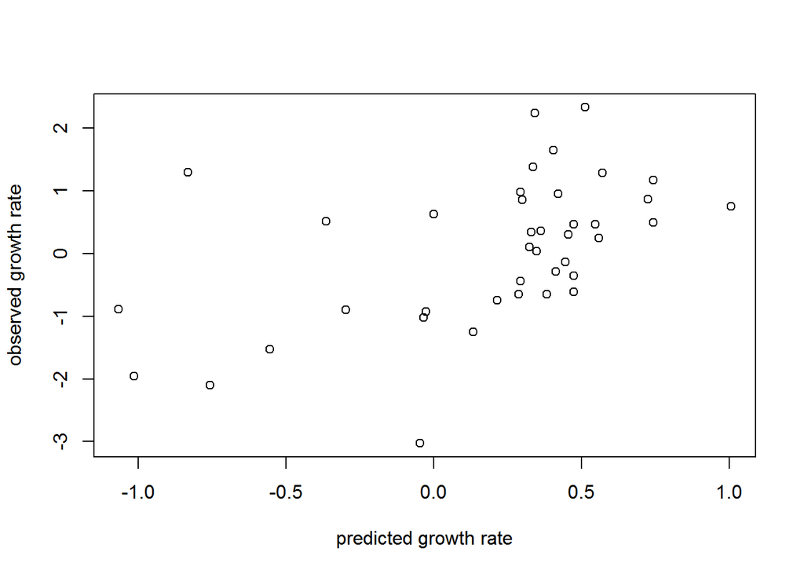

```r
set.seed(543)
train.id = sample(seq(1: nrow(thrip.ex2)), nrow(thrip.ex2)/2, replace=FALSE)
train.mod = lm(ratio~pop.log, data=thrip.ex2[train.id,])
y.pred = predict(train.mod, newdata=thrip.ex2[-train.id,])

plot(thrip.ex2[-train.id,"ratio"]~y.pred, xlab="predicted growth rate", ylab="observed growth rate")
```

```r
summary(lm(y.pred~thrip.ex2[-train.id,"ratio"]))
```

```
##
## Call:
## lm(formula = y.pred ~ thrip.ex2[-train.id, "ratio"])
##
## Residuals:
##     Min      1Q  Median      3Q     Max
## -1.2911 -0.1480  0.1148  0.2881  0.6611
##
## Coefficients:
##                               Estimate Std. Error t value Pr(>|t|)
## (Intercept)                    0.18612    0.06675   2.788 0.008228 **
## thrip.ex2[-train.id, "ratio"]  0.21119    0.05828   3.624 0.000847 ***
## ---
## Signif. codes:  0 '***' 0.001 '**' 0.01 '*' 0.05 '.' 0.1 ' ' 1
##
## Residual standard error: 0.4216 on 38 degrees of freedom
## Multiple R-squared:  0.2568, Adjusted R-squared:  0.2373
## F-statistic: 13.13 on 1 and 38 DF,  p-value: 0.0008466
```

> Plot observed vs predicted for both within- and out-of-fit data. Again, it would be more interesting to use your best model here (we know the Gompertz is bad for these data).

# Exercise 14

> Oscar, overall very nice indeed. There are a few places where you can polish the results and some points you might still find instructive. It’s OK too if you want to skip the third draft.  
> **Score: 29/30**